# SwiftKey Capstone

Rubén Orta Magán

March 19, 2016

# Executive Summary

The goal of this document is to deliver a report for the Capstone project. This is the last part in the Coursera Data Science Specialization. During this project we’ll analyze various text documents to discover how the data is structured. We’ll clean from non valuable words and with this data We’ll build a predictive model.

# Description of Data

This document includes an exploratory analysis of the data provided at the course information page. The data set contains files in Finnish, German, Russian, and English. Only English version is used in this project. The files processed are:

1. en_US.blogs.txt
2. en_US.news.txt
3. en_US.twitter.txt

We can show some basic stats of the content of the files previously to the cleaning phase.

```
##           File Name Line Counts Word Counts Character Counts
## 1   en_US.blogs.txt      899288    37334114        208623081
## 2    en_US.news.txt     1010242    34365936        205243643
## 3 en_US.twitter.txt     2360148    30359804        166816544
```

# Cleaning data sets

In this first report we’ll work only with 10% of the data included.

The package TM provides valuable functions to clean the data set. The data cleaning phase includes this actions.

```r
# http://www.cs.cmu.edu/~biglou/resources/bad-words.txt
bad_words <- read.csv("bad-words.txt", stringsAsFactors=FALSE, header = TRUE)
bad_words <- paste(bad_words, collapse=" ")
stop_words <- c("http", stopwords("english"), bad_words)

data <- tm_map(data_ori, removeWords, stop_words)
data <- tm_map(data, content_transformer(tolower))
data <- tm_map(data, stripWhitespace)
data <- tm_map(data, removePunctuation)
data <- tm_map(data, removeNumbers)
data <- tm_map(data, function(x) iconv(x, "latin1", "ASCII", sub=""))
data <- tm_map(data, PlainTextDocument)
data_clean <- tm_map(data, stripWhitespace)

dtm_blog <- DocumentTermMatrix(data_clean[1])
dtm_twitter <- DocumentTermMatrix(data_clean[2])
dtm_news <- DocumentTermMatrix(data_clean[3])

dtm_blog <- removeSparseTerms(dtm_blog, 0.95)
dtm_twitter <- removeSparseTerms(dtm_twitter, 0.95)
dtm_news <- removeSparseTerms(dtm_news, 0.95)
```

# Exploratory Analysis

```r
dtm <- dtm_twitter
freq <- sort(colSums(as.matrix(dtm)), decreasing=TRUE)
freq_equals_1 <- findFreqTerms(dtm, highfreq = 1)
```

We can see the 10 words with the higher frequency and how many words appears only once in the document.

```
##   the  said  will   one   new   can  also   but  year   two
## 25319 25046 10663  8439  7038  5896  5815  5794  5771  5713
```

```
## [1] 46420
```

We can expand the exploration showing a couple of plots related to the frequency of the word counts. The first example is a frequency plot with the words that appear at least 5000 times. The second one is a word cloud plot with words that appears at least 1500 times.

### Frequency plot

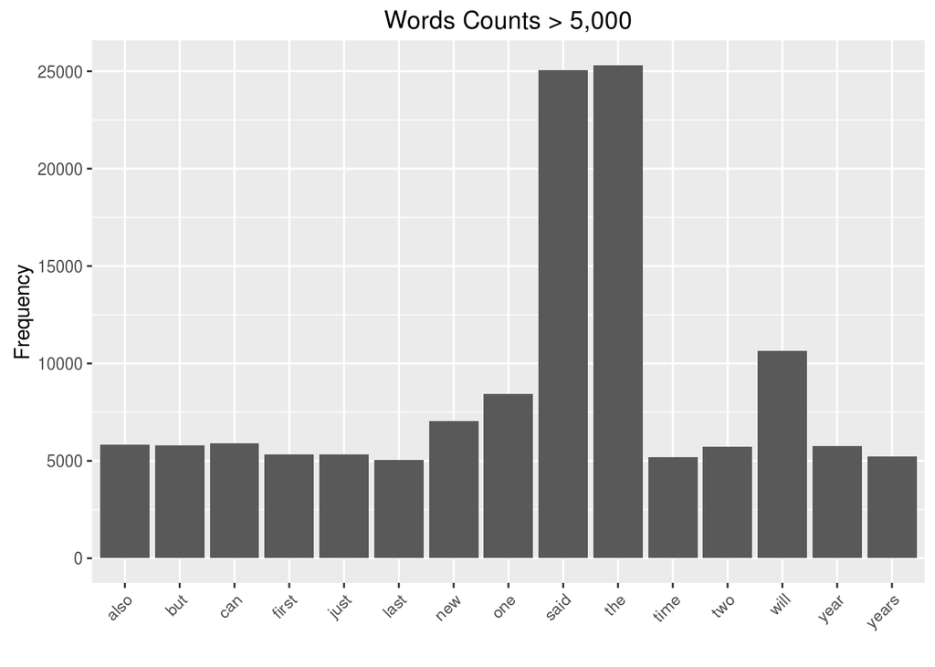

```r
wf <- data.frame(word=names(freq), freq=freq)
ggplot(wf[wf$freq > 5000, ], aes(x=word, y=freq)) +
  geom_bar(stat="identity") +
  xlab("") +
  ylab("Frequency") +
  theme(axis.text.x=element_text(angle=45, hjust=1)) +
  ggtitle("Words Counts > 5,000")
```

### Word cloud

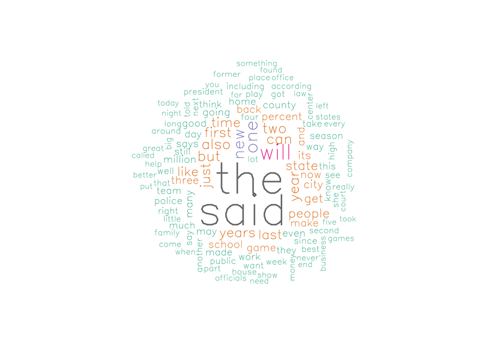

```r
pal <- brewer.pal(8,"Dark2")
wordcloud(names(freq), freq, min.freq=1500,
          max.words=Inf, random.order=FALSE, rot.per=.15,colors=pal,vfont=c("sans serif","plain") )
```

# Annex

## Blog Data

Top frequency words and Number of words with frequency one

```
##    the    one   will   just   like    can   time    get   know people
##  18827  12545  11477  10006   9882   9805   8803   7157   5928   5827
```

```
## [1] 50695
```

#### Frequency plot

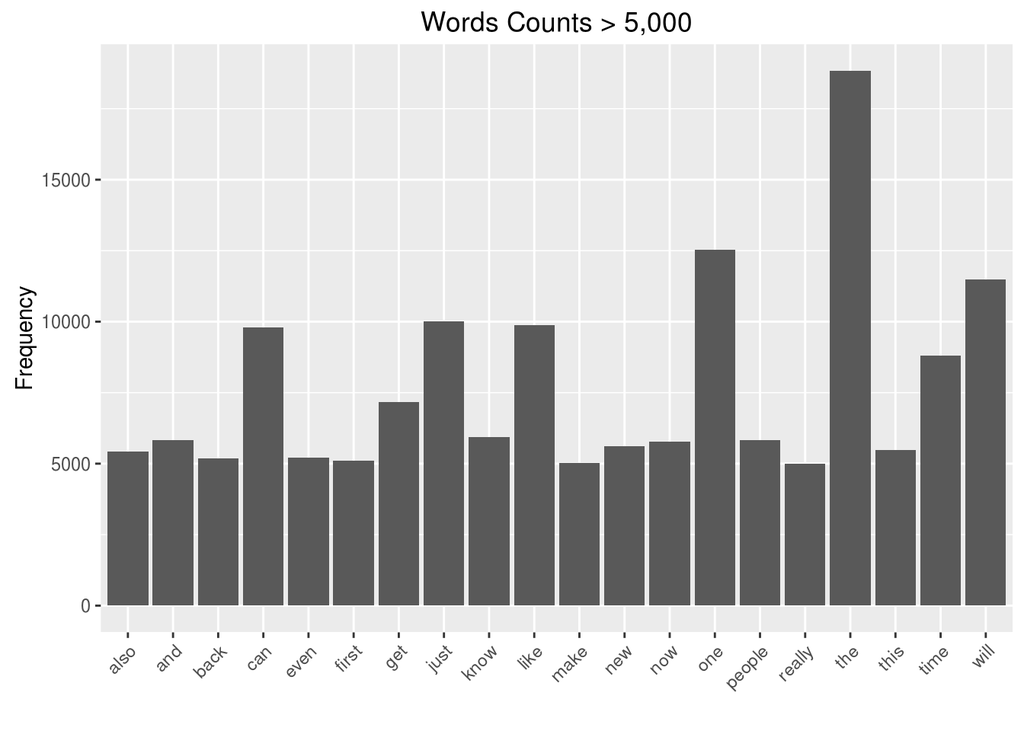

#### Word cloud

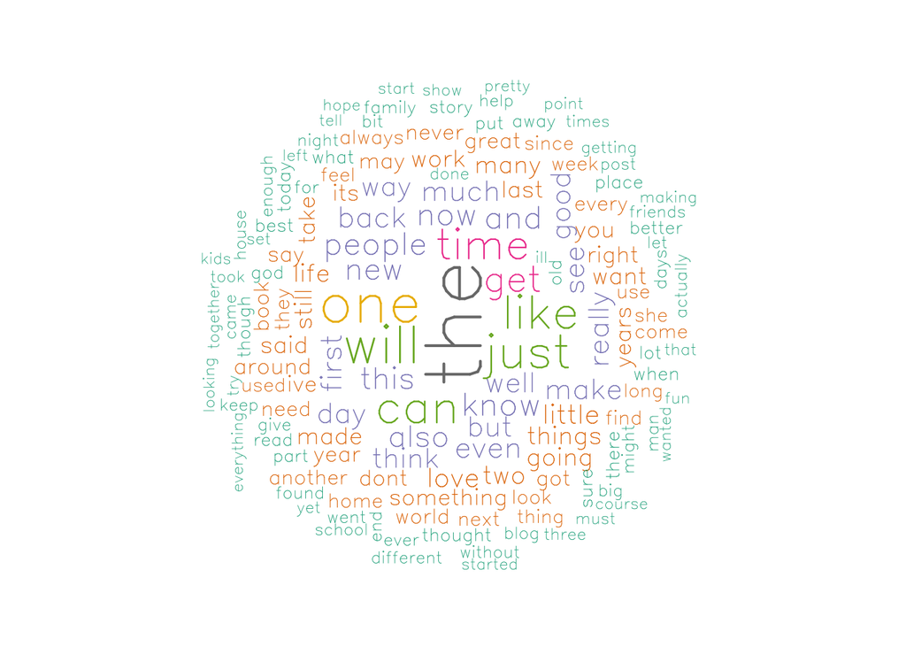

```
##   just   like    get   love   good   will    the thanks    day    can
##  15150  12143  11240  10417  10010   9409   9330   8981   8949   8788
```

```
## [1] 61455
```

#### Frequency plot

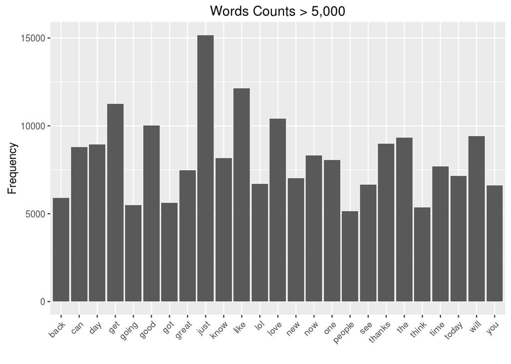

#### Wordcloud plot

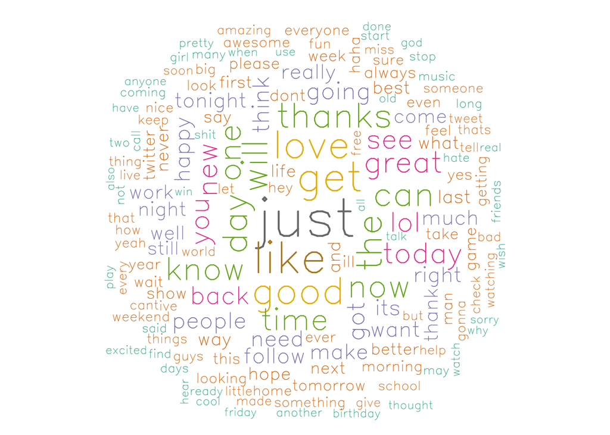